# Práctica1 - Estadística - Comparación de distribuciones de datos

## Estadística: Comparación de distribuciones de datos con Python

**Práctica:** Creando DataFrame, visualizaciones y comparaciones de estadísticos básicos.

**Objetivo:** Evaluar afirmaciones.

**Resource:** https://es.khanacademy.org/

**Carlos Prado | Córdoba Argentina**

Los miembros de una clase de música estaban discutiendo sobre qué instrumentos tocan los mejores estudiantes. Se hizo una encuesta, y aquí están los resultados:

Afirmar:

- a) Para los percusionistas, la mediana del promedio es "< | > | =" que la media.
- b) Para los saxofonistas, la mediana del promedio es "< | > | =" que la media.
- c) La desviación estándar del promedio de los flautistas es "< | > | =" que la desviación estándar del promedio de los saxofonistas.

```python
import pandas as pd
import numpy as np
```

## Creando DataFrame de datos con Pandas

```python
categoria = ["Flautista"] * 13 + ["Percusionista"] * 3 + ["Saxofonista"] * 9
valores = [0.3,0.3,0.3,0.3,0.3,0.3,0.3,0.3,0.3,0.3,0.3,0.3,0.3] + [2.4,2.8,3.2] + [3.9,3.9,3.9,3.9,4.0,4.0,4.0,4.0,4.0]
df = pd.DataFrame({"Estudiante": categoria, "Promedio": valores})
dfsum = pd.DataFrame({"Suma": valores})
dfc = pd.DataFrame({"Estudiante": categoria})
```

```python
df.head()
```

|  | Estudiante | Promedio |
| --- | --- | --- |
| 0 | Flautista | 0.3 |
| 1 | Flautista | 0.3 |
| 2 | Flautista | 0.3 |
| 3 | Flautista | 0.3 |
| 4 | Flautista | 0.3 |

### Descripción general de valores cuantitativos

```python
df.describe()
```

|  | Promedio |
| --- | --- |
| count | 25.000000 |
| mean | 1.916000 |
| std | 1.756815 |
| min | 0.300000 |
| 25% | 0.300000 |
| 50% | 0.300000 |
| 75% | 3.900000 |
| max | 4.000000 |

### Descripción general de valores categóricos

```python
dfc.describe()
```

|  | Estudiante |
| --- | --- |
| count | 25 |
| unique | 3 |
| top | Flautista |
| freq | 13 |

### Filtrado de grupos

```python
#grupo_flautistas = df['Estudiante']
```

```python
#grupo_flautistas[grupo_flautistas == "Flautista"]
```

```python
grupo1 = df['Promedio'].groupby(df['Estudiante'])
```

```python
grupo1.describe()
```

| Estudiante | count | mean | std | min | 25% | 50% | 75% | max |
| --- | --- | --- | --- | --- | --- | --- | --- | --- |
| Flautista | 13.0 | 0.300000 | 5.777784e-17 | 0.3 | 0.3 | 0.3 | 0.3 | 0.3 |
| Percusionista | 3.0 | 2.800000 | 4.000000e-01 | 2.4 | 2.6 | 2.8 | 3.0 | 3.2 |
| Saxofonista | 9.0 | 3.955556 | 5.270463e-02 | 3.9 | 3.9 | 4.0 | 4.0 | 4.0 |

```python
grupo1.median()
```

```
Estudiante
Flautista        0.3
Percusionista    2.8
Saxofonista      4.0
Name: Promedio, dtype: float64
```

```python
import matplotlib as plt
%matplotlib inline
```

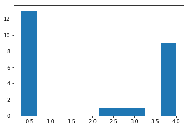

```python
plt.pyplot.hist(df['Promedio'])
```

```python
flautistas = df.loc[0:12, ['Estudiante','Promedio']]
flautistas.head()
```

|  | Estudiante | Promedio |
| --- | --- | --- |
| 0 | Flautista | 0.3 |
| 1 | Flautista | 0.3 |
| 2 | Flautista | 0.3 |
| 3 | Flautista | 0.3 |
| 4 | Flautista | 0.3 |

```python
flautistas.describe()
```

|  | Promedio |
| --- | --- |
| count | 1.300000e+01 |
| mean | 3.000000e-01 |
| std | 5.777784e-17 |
| min | 3.000000e-01 |
| 25% | 3.000000e-01 |
| 50% | 3.000000e-01 |
| 75% | 3.000000e-01 |
| max | 3.000000e-01 |

```python
std = flautistas.std(ddof=0)
var = flautistas.var(ddof=0)
print("Desviación tipica:",std,"Varianza:",var)
```

```
Desviación tipica: Promedio    5.551115e-17
dtype: float64 Varianza: Promedio    3.081488e-33
dtype: float64
```

```python
percusionistas = df.loc[13:15, ['Estudiante','Promedio']]
percusionistas
```

|  | Estudiante | Promedio |
| --- | --- | --- |
| 13 | Percusionista | 2.4 |
| 14 | Percusionista | 2.8 |
| 15 | Percusionista | 3.2 |

```python
percusionistas.describe()
```

|  | Promedio |
| --- | --- |
| count | 3.0 |
| mean | 2.8 |
| std | 0.4 |
| min | 2.4 |
| 25% | 2.6 |
| 50% | 2.8 |
| 75% | 3.0 |
| max | 3.2 |

```python
std = percusionistas.std(ddof=0)
var = percusionistas.var(ddof=0)
media = percusionistas.median()
print("Desviación tipica:",std,"Varianza:",var,"media",media)
```

```
Desviación tipica: Promedio    0.326599
dtype: float64 Varianza: Promedio    0.106667
dtype: float64 media Promedio    2.8
dtype: float64
```

```python
saxofonistas = df.loc[16:24, ['Estudiante','Promedio']]
saxofonistas
```

|  | Estudiante | Promedio |
| --- | --- | --- |
| 16 | Saxofonista | 3.9 |
| 17 | Saxofonista | 3.9 |
| 18 | Saxofonista | 3.9 |
| 19 | Saxofonista | 3.9 |
| 20 | Saxofonista | 4.0 |
| 21 | Saxofonista | 4.0 |
| 22 | Saxofonista | 4.0 |
| 23 | Saxofonista | 4.0 |
| 24 | Saxofonista | 4.0 |

```python
saxofonistas.describe()
```

|  | Promedio |
| --- | --- |
| count | 9.000000 |
| mean | 3.955556 |
| std | 0.052705 |
| min | 3.900000 |
| 25% | 3.900000 |
| 50% | 4.000000 |
| 75% | 4.000000 |
| max | 4.000000 |

```python
std = saxofonistas.std(ddof=0)
var = saxofonistas.var(ddof=0)
mediana = saxofonistas.median()
print("Desviación tipica:",std,"Varianza:",var,"Mediana:",mediana)
```

```
Desviación tipica: Promedio    0.04969
dtype: float64 Varianza: Promedio    0.002469
dtype: float64 Mediana: Promedio    4.0
dtype: float64
```

Respuesta

- a)Para los percusionistas, la mediana del promedio es " = " que la media.
  - mean = 2.8
  - median = 2.8
- b) Para los saxofonistas, la mediana del promedio es " > " que la media.
  - mean = 3.955556
  - median = 4.0
  - std = 0.04969
- c) La desviación estándar del promedio de los flautistas es " < " que la desviación estándar del promedio de los saxofonistas.
  - std flautista = 5.777784e-17
  - std saxofonista = 5.270463e-02